**Lab #3 Markdown File**

[**Lab Instructions**](https://dssoc.github.io/assignments/lab_instructions.html)

In this lab we will practice using the `ggplot2` library to create visualizations of our data. **Our standard for visualizations is that each plot should have axis labels, all labels must be readable to someone unfamiliar with your data (e.g. Female and Male instead of `F` and `M`, Senator and Representative instead of `rep` and `sen`), and we should easily be able to tell what your figure is showing. Failure to do this will result in point deductions.**

See the “Instructions” section of the [Introduction to Lab Assignments](https://dssoc.github.io/assignments/lab_instructions.html) page for more information about the labs. That page also gives descriptions for the datasets we will be using.

**Required reading:**

- [R for Data Science Chapter 13: Relational data](https://r4ds.had.co.nz/relational-data.html)
- [R for Data Science Chapter 3: Data visualization](https://r4ds.had.co.nz/data-visualisation.html)
- [R for Data Science Chapter 28: Graphics for communication](https://r4ds.had.co.nz/graphics-for-communication.html)

**Optional resources:**

- [R for Data Science Chapter 16: Dates and times](https://r4ds.had.co.nz/dates-and-times.html)
- [Grouped, stacked and percent stacked barplot in ggplot2](https://www.r-graph-gallery.com/48-grouped-barplot-with-ggplot2.html)

## Example Questions

**ex1. make a bar chart showing the number of male and female members of congress in our dataset.**

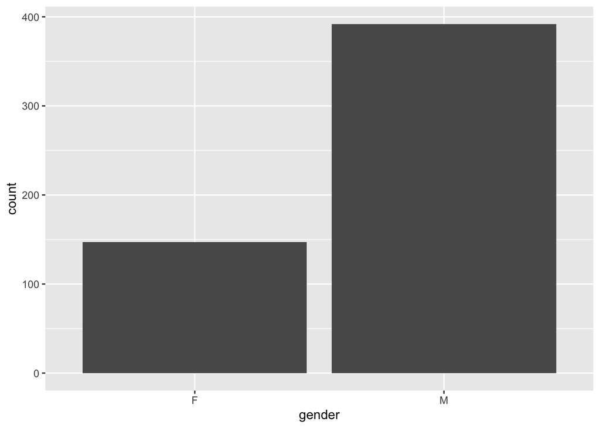

```r
congress %>%
  ggplot(aes(x=gender)) +
    geom_bar()
```

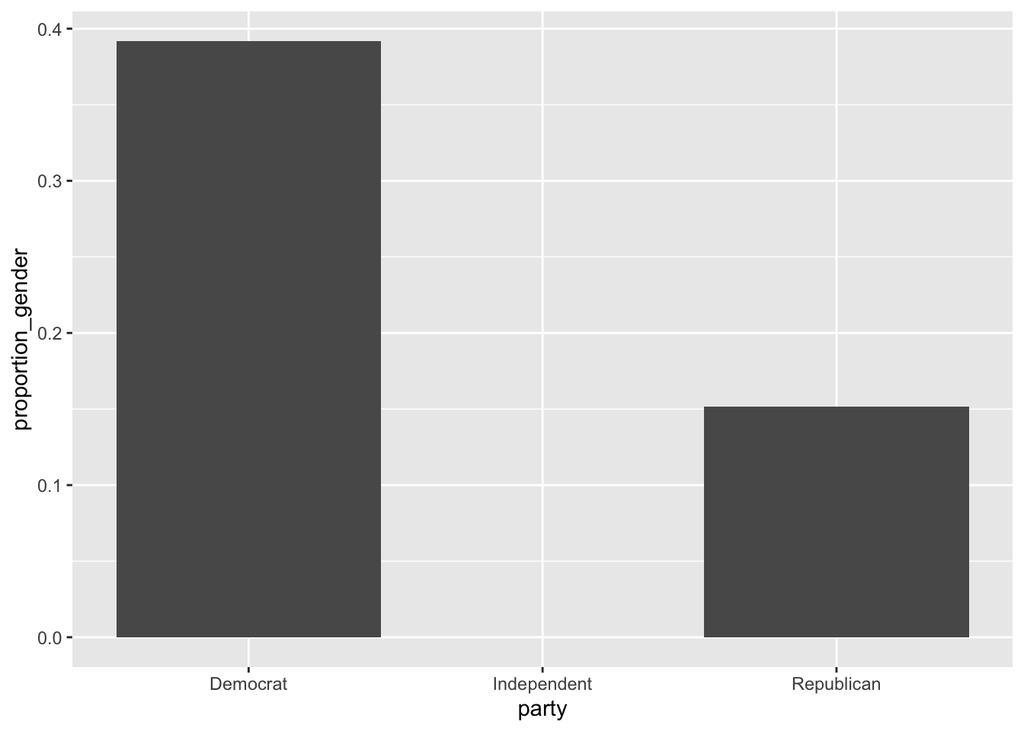

```r
congress %>%
  group_by(party) %>%
  summarize(proportion_gender=mean(gender=='F')) %>%
  ggplot(aes(x=party, y=proportion_gender)) +
    geom_bar(stat='identity', position='dodge')
```

## Questions

**1. Describe the functionality of each of the following functions:**

```
group_by: Groups variables in a column, orders in ascending order to be used to aggregate data using summarise(); doesn't produce any output on its own. (ex: to calculuate the mean of each country, you can group_by country and then pipe into summarise.)
summarise: Creates a new data frame and returns rows that combines the grouped variables of summary data.
inner_join: Keeps observations from one data frame that have a matching observation in another data frame
left_join: Keeps observations that are in the first data frame
ggplot: Takes in data to create plots
```

**2. Create a bar plot to show the average ages of congress members from each political party. Now do the same for M and F genders.**

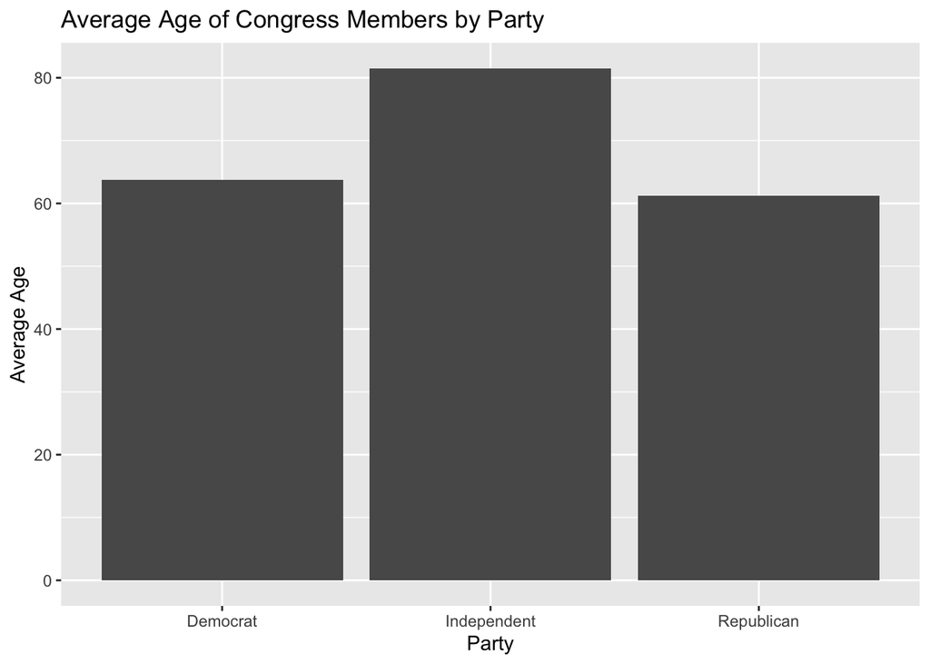

```r
congress %>%
  group_by(party) %>%
  summarize(proportion_age=mean(2024 - birthyear)) %>%
  ggplot(aes(x=party, y=proportion_age)) +
    geom_bar(stat='identity', position='dodge') +
    labs(y = 'Average Age', x = 'Party', title = 'Average Age of Congress Members by Party')
```

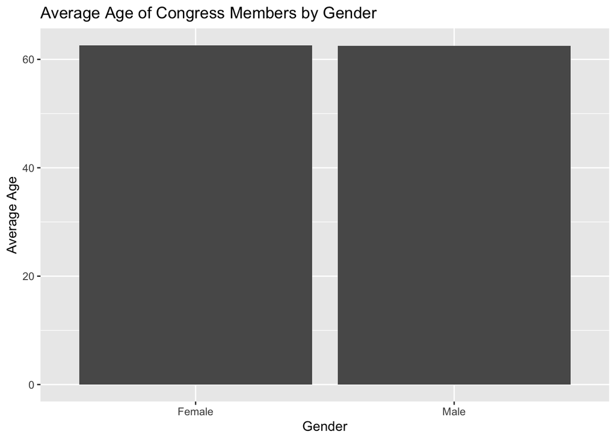

```r
congress %>%
  group_by(gender) %>%
  summarize(proportion_gender=mean(2024 - birthyear)) %>%
  ggplot(aes(x=gender, y=proportion_gender)) +
    geom_bar(stat='identity', position='dodge') +
    labs(y = 'Average Age', x = 'Gender', title = 'Average Age of Congress Members by Gender') +
    scale_x_discrete(labels = c("F" = "Female", "M" = "Male"))
```

**3. Create a line graph showing the total number of congress member births in each decade since the 1930’s, with separate lines for senate and house members (see the `type` column). The labels on your x-axis should look like “1930’s”, “1940’s”, and so on, and your legend should show names “Senator” and “Representative” (i.e. not `rep` and `sen`).**

Note: The plotted lines may not show up in decades where there were no births - that is okay.

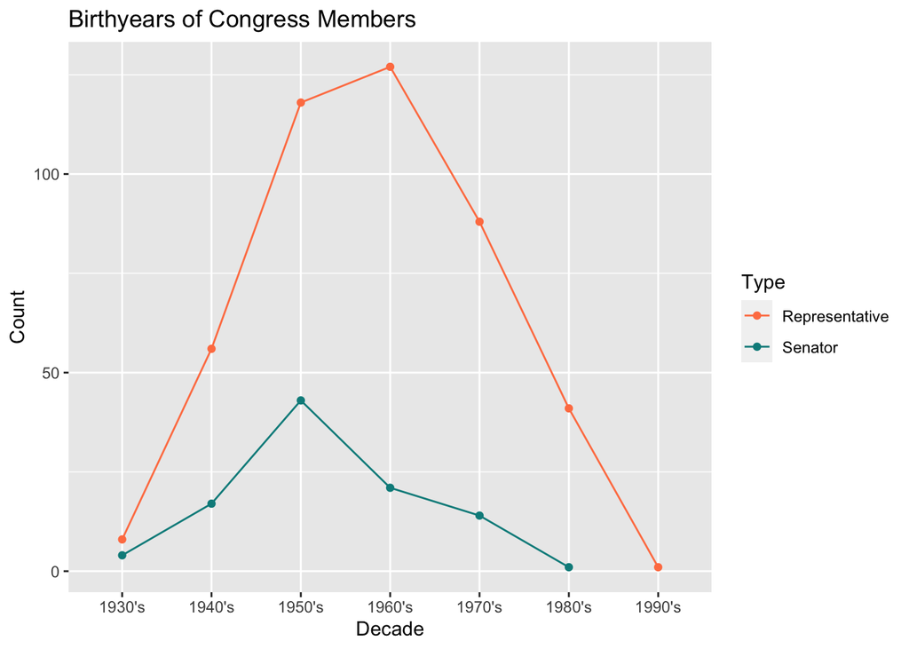

```r
congress %>%
  mutate(decade = sprintf("%d's", floor(birthyear/10)*10)) %>%
  count(decade, type) %>%
  ggplot(aes(x=decade, y=n, color=type, group=type)) +
  xlab("Decade") +
    ylab("Count") +
  labs(title="Birthyears of Congress Members") +
  geom_line() +
  geom_point() +
  scale_colour_manual("Type",values=c("coral", "cyan4"), labels=c("Representative","Senator"))
```

**4. Create a bar chart showing the average ages of Senators and Representatives separately by weekday. The plot should make it easy to compare Senators and Representatives within each weekday. The x-labels should be weekday names and appear in chronological order.**

NOTE: For convenience, I have already parsed the `birthdate` column into a `date` type.

NOTE: the final plot should have 14 bars: 7 weekdays by 2 types of congress members (Senators and Representatives).

HINT: see the Optional Readings for more information about grouped bar charts using `ggplot2`.

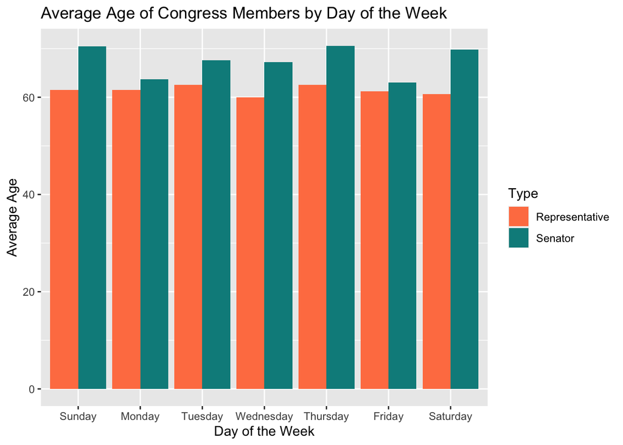

```r
congress %>%
  mutate(weekday=weekdays(birthdate)) %>%
  group_by(type, weekday) %>%
  summarize(proportion_age=mean(2024 - birthyear)) %>%
  ggplot(aes(fill=type, y=proportion_age, x=weekday)) +
  geom_bar(position="dodge", stat="identity") +
  scale_fill_manual("Type",values=c("coral", "cyan4"), labels=c("Representative","Senator")) +
  scale_x_discrete(limits = c("Sunday", "Monday", "Tuesday", "Wednesday", "Thursday", "Friday", "Saturday")) +
  ylab("Average Age") +
  xlab("Day of the Week") +
  labs(title = "Average Age of Congress Members by Day of the Week")
```

```r
# mapping FILL aesthetic
```

**5. Use an inner join to combine the columns of the `congress` dataframe with the columns of `congress_contacts` and show the average proportion of congress members with valid Facebook accounts by gender.**

HINT: you will want to join the dataframes based on a column that is common to both datasets.

```r
congress %>%
  inner_join(congress_contact, by="bioguide_id") %>%
  group_by(gender) %>%
  summarise(prop_facebook_valid = mean(facebook !=''))
```

```
## # A tibble: 2 × 2
##   gender prop_facebook_valid
##   <fct>                <dbl>
## 1 F                    0.571
## 2 M                    0.737
```

**6. Create a bar chart comparing the average age of congress members that have valid Twitter, Facebook, and YouTube accounts. Each bar should correspond to a social media platform and the height should correspond to the average age of congress members with that type of account.**

HINT: one way to accomplish this is by using gather to create a separate row for each person-account, and summarize to average by age.

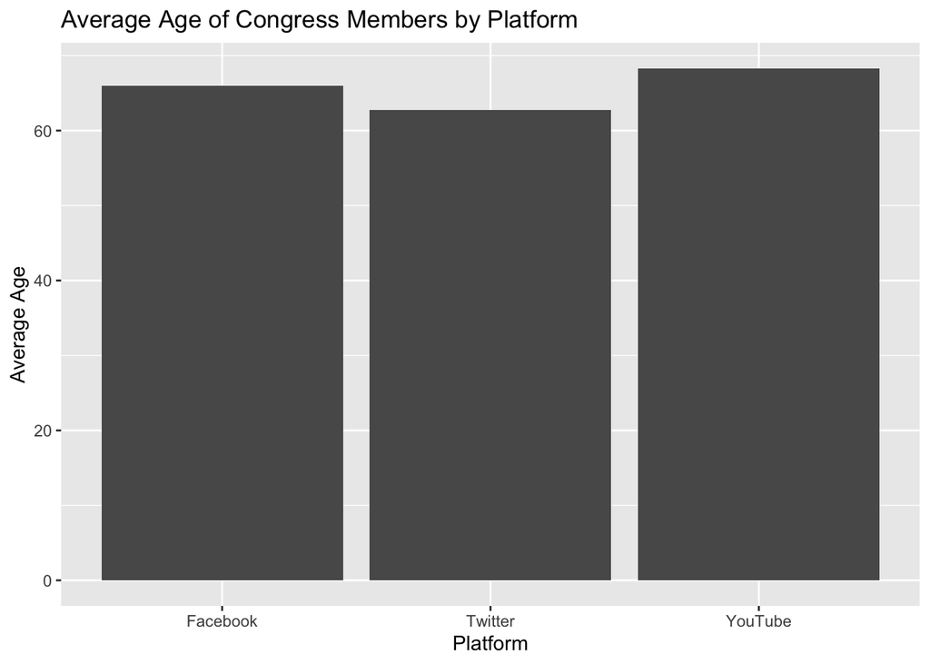

```r
congress %>%
  inner_join(congress_contact, by="bioguide_id") %>%
  gather(key=platform, value=username, twitter, facebook, youtube) %>%
  group_by(platform) %>%
  filter(username!='') %>%
  summarise(average_age = mean(2024-birthyear)) %>%
  ggplot(aes(x=platform, y=average_age)) +
  geom_bar(stat='identity', position='dodge') +
    labs(y = 'Average Age', x = 'Platform', title = 'Average Age of Congress Members by Platform') +
    scale_x_discrete(labels = c("facebook" = "Facebook", "twitter" = "Twitter", "youtube" = "YouTube"))
```

**7. The remainder of problems in this homework will involve the use of the `committees.RData` dataset. Create a plot showing the average number of subcommittees that congress members belong to by gender.**

HINT: as described in the Lab Instructions page, you will need to perform a join between the `subcommittees` and `committee_memberships` dataframes to get ONLY subcommittee (and not committee) memberships. You may copy-paste the code from the Lab Instructions page if that would be helpful.

HINT: you should perform a join to get ONLY subcommittee (and not committee) memberships. Refer to the Lab Instructions page for more information about this dataset.

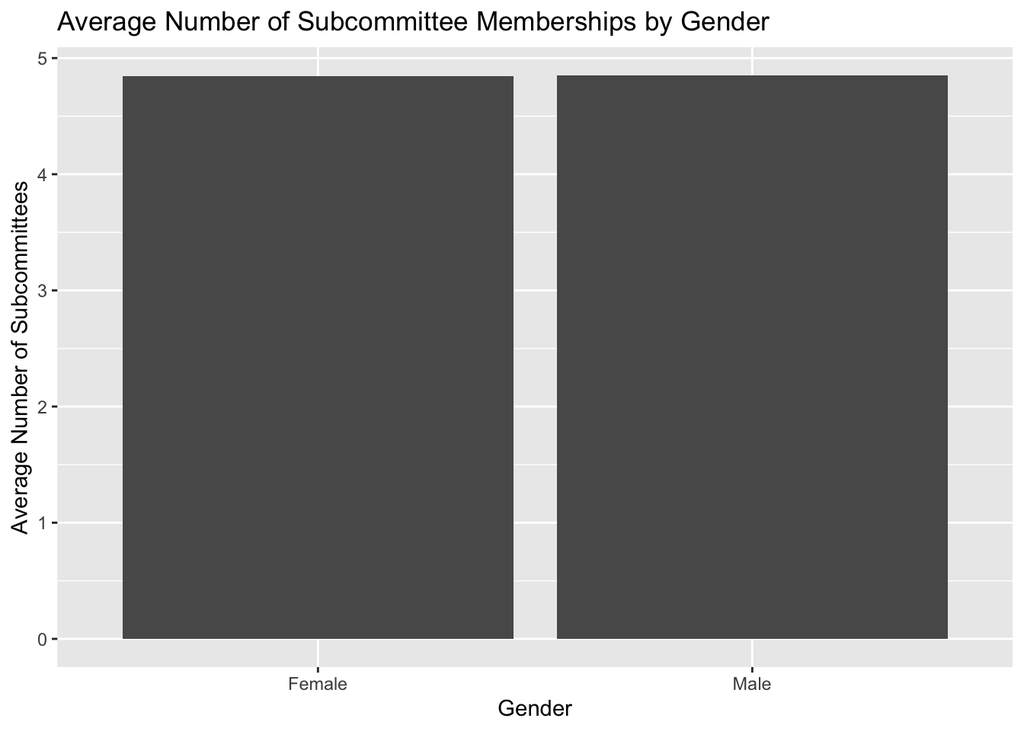

```r
subcommittees %>%
  inner_join(committee_memberships, by="thomas_id") %>%
  right_join(congress, by="bioguide_id") %>%
  group_by(full_name, gender) %>%
  summarise(num_membership = sum(!is.na(name))) %>%
  group_by(gender) %>%
  summarise(avg_subcommittee_membership = mean(num_membership)) %>%
  ggplot(aes(x=gender, y=avg_subcommittee_membership)) +
    geom_bar(stat='identity', position='dodge') +
    labs(y = 'Average Number of Subcommittees', x = 'Gender', title = 'Average Number of Subcommittee Memberships by Gender') +
    scale_x_discrete(labels = c("F" = "Female", "M" = "Male"))
```

**8. Create a bar plot showing the number of members that belong to the 5 largest full congressional committees (i.e. full committees with the largest number of members). The bars should be sorted based on committee sizes.**

NOTE: read the Lab Instructions page for more information about the standards for visualizations in this course. The full committee names should appear somewhere on the plot - please do not provide `thomas_id`s only (you may include full committee names in the legend though).

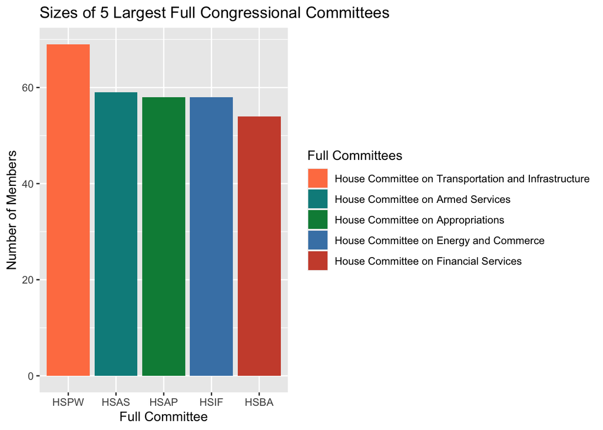

```r
committees %>%
  inner_join(committee_memberships, by="thomas_id") %>%
  count(thomas_id) %>%
  top_n(5, n) %>%
  ggplot(aes(fill=thomas_id, x=reorder(thomas_id, -n), y=n)) +
    geom_bar(stat='identity', position='dodge') +
    scale_fill_manual("Full Committees",
                      values=c("coral", "cyan4", "springgreen4", "steelblue", "tomato3"),
                      breaks = c("HSPW", "HSAS", "HSAP", "HSIF", "HSBA"),
                      labels=c("House Committee on Transportation and Infrastructure","House Committee on Armed Services", "House Committee on Appropriations", "House Committee on Energy and Commerce", "House Committee on Financial Services")) +
  labs(x = "Full Committee", y = "Number of Members", title = "Sizes of 5 Largest Full Congressional Committees")
```

**9. Create a single bar plot that shows the average age of the full committees with the 5 highest and lowest average ages. The bars should be sorted based on average committee ages.**

This means you will need to join three dataframes: `committee_memberships` for membership information, `committees` to separate full committees from subcommittees and get committee names, and `congress` to get age information.

```r
average_age <- committees %>%
  inner_join(committee_memberships, by="thomas_id") %>%
  inner_join(congress, by="bioguide_id") %>%
  group_by(name, thomas_id) %>%
  summarize(average_age = mean(2024-birthyear)) %>%
  arrange(average_age)
```

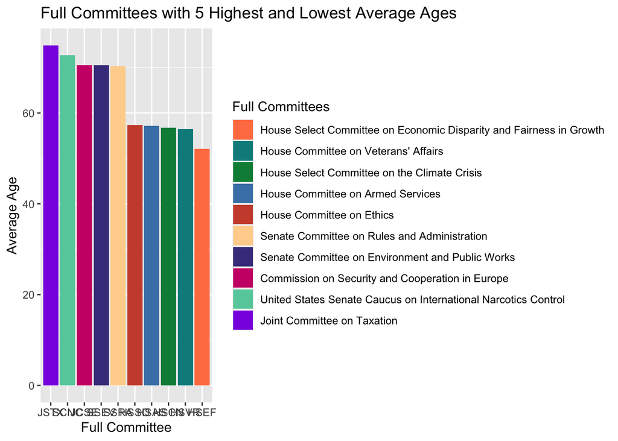

```r
average_age %>%
  head(5) %>%
  bind_rows(tail(average_age, 5)) %>%
  ggplot(aes(fill=thomas_id, x=reorder(thomas_id, -average_age), y=average_age)) +
  geom_bar(stat='identity', position='dodge') +
  scale_fill_manual("Full Committees",
                      values=c("coral", "cyan4", "springgreen4", "steelblue", "tomato3", "burlywood1", "darkslateblue", "deeppink3", "aquamarine3", "blueviolet"),
                      breaks = c("HSEF", "HSVR", "HSCN", "HSAS", "HSSO", "SSRA", "SSEV", "JCSE", "SCNC", "JSTX"),
                      labels=c("House Select Committee on Economic Disparity and Fairness in Growth","House Committee on Veterans' Affairs", "House Select Committee on the Climate Crisis", "House Committee on Armed Services", "House Committee on Ethics", "Senate Committee on Rules and Administration", "Senate Committee on Environment and Public Works", "Commission on Security and Cooperation in Europe", "United States Senate Caucus on International Narcotics Control", "Joint Committee on Taxation")) +
    labs(x = "Full Committee", y = "Average Age", title = "Full Committees with 5 Highest and Lowest Average Ages")
```

**10. Using the topics you described last week or a new topic you have been thinking about, describe two social science questions that you would be interested in exploring for your final project. Do you think these questions might be answerable using real data?**

```
Topic: Museums
Question: Has the increase of innovations in technology increased museum interest or resulted in lower visitor rates?

Topic: National Parks
Question: What factors influence higher visitor rates at National Parks, including monuments and other historical locations?

I think about of these questions are answerable with real data, though data regarding the National Parks might be easier to obtain than visitor data from museums that could be under a private domain. I assume that Google likely contains a lot of data regarding visitors at locations, along with reviews that are date-stamped. I think that these questions would be more feasible if they were narrower in scope.
```